# Project 1

Madison Pascual

2024-09-27

# **Introduction**

The dataset for this analysis comprises the [*Top 500 ranked albums* according to Rolling Stone in 2020](https://pudding.cool/2024/03/greatest-music/). These albums represent some of the most influential and popular works in music history, spaning a wide variety of time periods and genres, from 1955 to 2019 and Electronic to Latin. The dataset includes key information about each album, such as the year it was released, the genre and type of album, and numeric metrics including the number of weeks an album stayed on the [Billboard charts](https://www.billboard.com/charts/), its highest position on the Billboard charts, and its [Spotify](https://open.spotify.com/) popularity.

To find out how Spotify songs are ranked by popularity, visit [this website.](https://www.artist.tools/features/spotify-popularity-index#:~:text=This%20score%20is%20calculated%20based,your%20music%20performs%20over%20time.)

The outcome variable of interest is each albums’ **peak billboard position**, while the predictor variables are **whether or not the albums spent at least 20 weeks on the Billboard charts**, **the albums’ genres**, and their **Spotify popularity**.

[figure not shown]

Hear the Trailer for Season 2 of Rolling Stone’s ‘500 Greatest Albums’ Podcast

# **Outcome Variable**

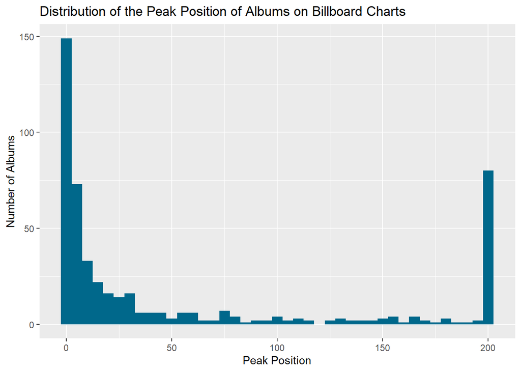

The graph is **skewed right, with 195 albums having peaked between the top 1 and top 5 position on the Billboard charts.** The minimum value of the peak position any album received (which is the best position achievable) is 1. The Q1 of the peak positions is 2. The median of the peak positions is 12. The mean of the peak positions is 56. The Q3 of the peak positions is 94. The maximum of the peak positions is 201 (which is the worst position achievable).

# **Bivariate Analyses**

### **Analysis 1**

[figure not shown]

The correlation coefficient of the relationship between if an album has ever peaked at 1 and if an album has spent at least 20 weeks on the Billboard charts is **0.3102696.** There is a **moderate positive relationship,** which means there is some level of association between an album’s peak and its time on the Billboard charts.

### **Analysis 2**

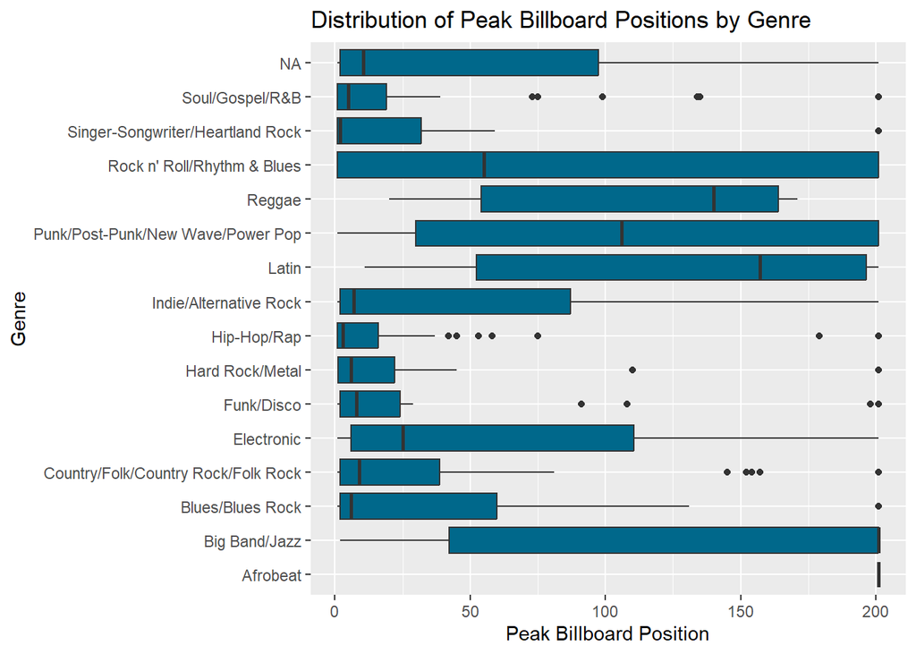

As the graph shows, **the highest peak billboard position mean of all the genres is Afrobeats with an average of 201** because the genre only had 2 albums to represent it, and both albums had a peak position of 201. Next are Big Band/Jazz with a mean position of 132, Latin with a mean position of 125.5, Punk/Post-Pink/New Wave/Power Pop with a mean position of 112, Reggae with a mean position of 109.9, Rock n’ Roll/Rhythm & Blues with a mean position of 83.3, Electronic with a mean position of 66.7, Indie/Alternative Rock with a mean position of 52.6, Blues/Blues Rock with a mean position of 48.1, Country/Folk/Country Rock/Folk Rock with a mean position of 46, Singer-Songwriter/Heartland Rock with a mean position of 45.6, Funk/Disco with a mean position of 37.6, Soul/Gospel/R&B with a mean position of 34.8, Hard Rock/Metal with a mean position of 26.3, and , **Hip-Hop/Rap with the lowest mean peak position of 20.4.**